## `pttR` 套件架構

> I believe that packages … should strive to do one thing and do it well.

> – Hadley Wickham, *R Packages*, p. 99

讓`pttR`聚焦在資料前處理，將後續較複雜的功能做成其它套件？

### `pttR`目標

1. 降低取得 PTT 資料的難度
2. 符合 PTT 的斷詞處理
3. 與 R Text Mining 套件銜接

## How (I think) `pttR` Should Work

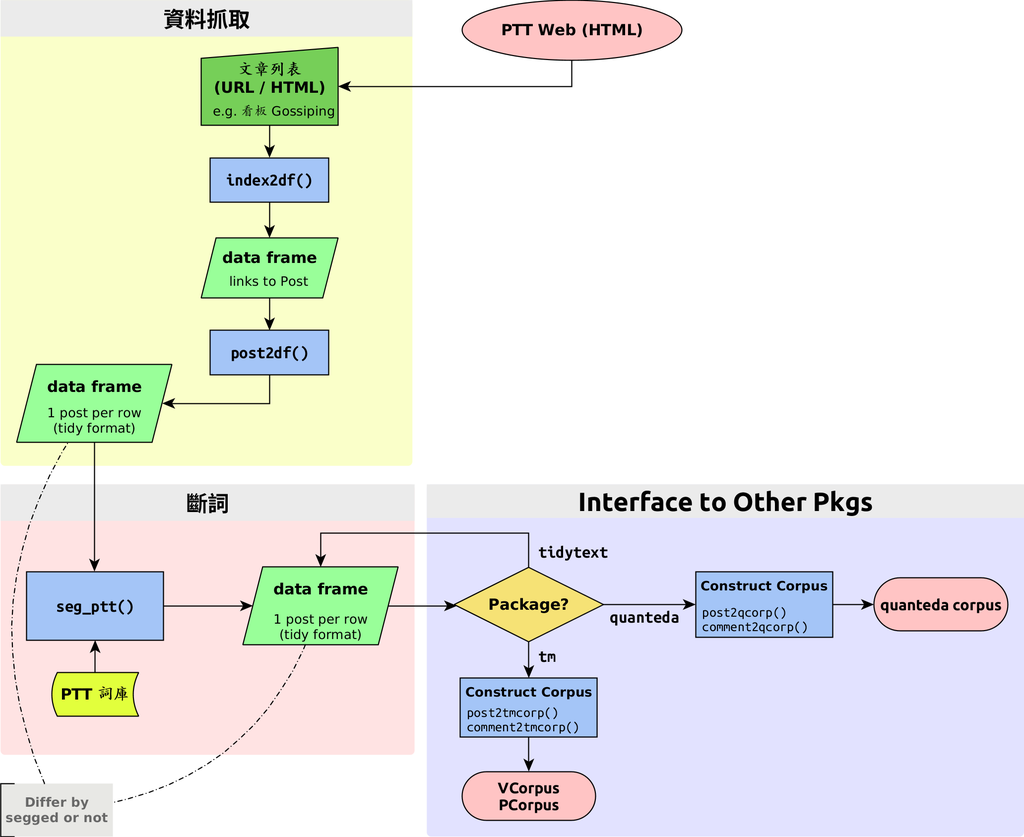

## 未完成：**斷詞**

目前想法：

- 透過 jiebaR 自訂詞庫斷詞
- 建立詞庫，維護更新供使用者下載
  - 現存資源：[PTT 鄉民百科](http://zh.pttpedia.wikia.com/wiki/) (需要 Scrapy)
  - **新詞辨識**
    - [簡單實作](http://www.matrix67.com/blog/archives/5044)：

    > 文本片段的**凝固程度**和**自由程度**，两种判断标准缺一不可。只看凝固程度的话，程序会找出「巧克」、「俄罗」、「颜六色」、「柴可夫」等实际上是「半个词」的片段；只看自由程度的话，程序则会把「吃了一顿」、「看了一遍」、「睡了一晚」、「去了一趟」中的「了一」提取出来，因为它的左右邻字都太丰富了。

    > 我们把文本中出现过的所有长度不超过 d 的子串都当作潜在的词（即候选词，其中 d 为自己设定的候选词长度上限，我设定的值为 5 ），再为**出现频数**、**凝固程度**和**自由程度**各设定一个阈值，然后只需要**提取出所有满足阈值要求的候选词**即可。